# hw6

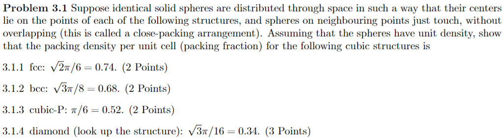

For each of these, we will find the separation between each atom and divide by two to get the sphere radius, then find what portion of the sphere is in the unit cell. I suspect it will be proportional to the number of atoms contained in the unit cell (1/8 for edges, 1/2 for face, etc)

It isn't necessarily true that all lattice points will be equidistant, but all spheres will have radius equal to the smallest radius. Rather than calculate all radii possible and selecting the shortest, we'll do something...

3.1.1 fcc $(000)$ and $\left(0\frac{1}{2}\frac{1}{2}\right)$ will yield the smallest radius

$$ \sqrt{0 + \left( \frac{1}{2}\right)^2+ \left( \frac{1}{2}\right)^2} = \frac{\sqrt{2}}{2} \\ r = \frac{\sqrt{2}}{4} \\ V = \frac{4}{3}\pi r^3 = \pi \frac{\sqrt{2}}{24} $$

FCC:

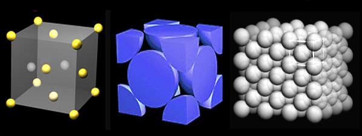

https://www.nde-ed.org/Physics/Materials/Structure/metallic_structures.xhtml

Using the fact that 1/2 points (face) contribute 1/2 spheres, 1/8 points for corners, we get

$$ $$

$$ 8*\frac{1}{8} V + 6 * \frac{1}{2} V = 4V = \pi \frac{\sqrt{2}}{6} $$

3.1.2

Volume per sphere: $(000)$ and $(\frac{1}{2}\frac{1}{2}\frac{1}{2})$ will yield the smallest radius

$$ \sqrt{3\left(\frac{1}{2} \right)^2} = \frac{\sqrt{3}}{2} \\ r = \frac{\sqrt{3}}{4} \\ V = \frac{4}{3}\pi r^3 =\pi \frac{\sqrt{3}}{16} $$

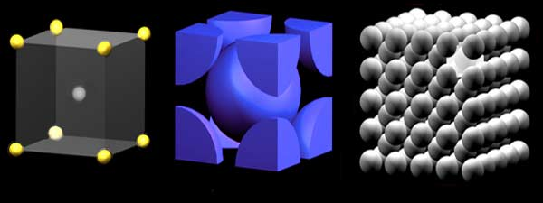

Eight corners, one full (center)

$$8*1/8 + 1*1 = 2 \\ 2V = \pi\frac{\sqrt{3}}{8}$$

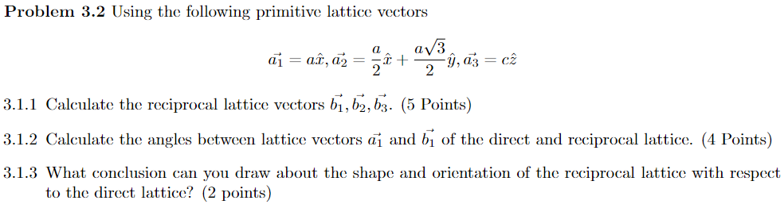

3.1.1 (actually 3.2.1) - use formula

$$ \vec b_i = 2\pi \frac{\vec a_j \times \vec a_k}{\vec a_1 \cdot \left( \vec a_2 \times \vec a_3\right)} $$

First find the denomonator

$$ \vec a_1 \cdot \left( \vec a_2 \times \vec a_3\right) = a\hat x \cdot \left( \left( 1/2 a\hat x + \sqrt{3}/2 a\hat y \right) \times c \hat z\right) \\ = \frac{\sqrt{3}}{2} a^2 c \\ $$

For each cross product we have

$$ a_2 \times a_3 = \frac{\sqrt{3}}{2} ac \hat x - \frac{ac}{2} \hat y \\ a_3 \times a_1 = ac\hat y \\ a_1 \times a_2 = \frac{\sqrt{3}}{2} a^2 \hat z $$

Thus our reciprocal vectors are

$$ b_1 = 2\pi\left[ \frac{1}{a}\hat x-\frac{\sqrt{3}}{3a} \hat y\right]\\ b_2 = 2\pi \frac{2\sqrt{3}}{3a} \hat y\\ b_3 =2\pi \frac{1}{c} \hat z $$

3.1.2 angles:

```python
from numpy import sqrt, arccos

arccos(6/(4*sqrt(3)))
```

```
0.5235987755982987
```

The reciprocal lattice isn't orthogonal to the direct lattice. It is oriented in a different direction.